# 数据科学与社会研究 第四讲、夯基：关于R的基础

2018 Oct 25

## R语言基础

- 数据框与变量操作
- R中其他数据对象
- 基础统计
- R条件语句与循环

## 从数据框到R工作环境

## 数据框与变量处理

- 数据框导入与创建
- 数据的索引
- 数据排序与类型
- 创建和修改变量

## 数据框:导入

用过Excel、SPSS、stata应知道数据（data）是一种矩阵。列表示变量，行表示案例。各列类型可以不同但长度通常一致。在R中，我们称之为数据框(Data frame)。

```r
data <- read.csv("../data/people.csv")
knitr::kable(data)
```

| city | age | gender | edu |
| --- | --- | --- | --- |
| beijing | 23 | F | elementary |
| shanghai | 43 | M | high school |
| chengdu | 51 | F | college |
| shanghai | 32 | F | middle school |
| beijing | 60 | M | elementary |

## 数据框：构建数据框

```r
# 构建向量：注意三个一样长
city  <- c('beijing','shanghai','chengdu','shanghai','beijing')
age <- c(23,43,51,32,60)
gender <- c('F','M','F','F','M')

#合成数据框：3个变量
people <- data.frame(city,age,gender)
print(people)
```

```
##       city age gender
## 1  beijing  23      F
## 2 shanghai  43      M
## 3  chengdu  51      F
## 4 shanghai  32      F
## 5  beijing  60      M
```

## 数据框

探索基本属性

```r
summary(people)
```

```
##        city        age       gender
##  beijing :2   Min.   :23.0   F:3
##  chengdu :1   1st Qu.:32.0   M:2
##  shanghai:2   Median :43.0
##               Mean   :41.8
##               3rd Qu.:51.0
##               Max.   :60.0
```

```r
dim(people)
```

```
## [1] 5 3
```

```r
class(people)
```

```
## [1] "data.frame"
```

summary函数负责对每列进行统计，dim得到维度信息。

## 数据框：基本属性

```r
head(people,2)
```

```
##       city age gender
## 1  beijing  23      F
## 2 shanghai  43      M
```

```r
str(people)
```

```
## 'data.frame':    5 obs. of  3 variables:
##  $ city  : Factor w/ 3 levels "beijing","chengdu",..: 1 3 2 3 1
##  $ age   : num  23 43 51 32 60
##  $ gender: Factor w/ 2 levels "F","M": 1 2 1 1 2
```

head默认得到前六行数据，而str返回整个数据的结构。

## 数据框：变量名

```r
names(data)
```

```
## [1] "city"   "age"    "gender" "edu"
```

```r
# 更改变量名
names(data)[1:2] <- c("bigcity", "age2")
data$bigcity
```

```
## [1] beijing  shanghai chengdu  shanghai beijing
## Levels: beijing chengdu shanghai
```

```r
names(data)[1:2] <- c("city", "age")
names(data)[1:2]
```

```
## [1] "city" "age"
```

## 数据框：筛选部分变量

用`$`符号或者`[ ]`来提取部分变量

```r
people[2]   # 等价于 people[, 'age']
```

```
##   age
## 1  23
## 2  43
## 3  51
## 4  32
## 5  60
```

```r
people[,2]   # 等价于 people[, 'age'] 或者 people$age
```

```
## [1] 23 43 51 32 60
```

```r
people[,2:3] # 等价于 people[, c('age','gender')]
```

```
##   age gender
## 1  23      F
## 2  43      M
## 3  51      F
## 4  32      F
## 5  60      M
```

## 数据框:筛选部分案例

```r
people[1:2,] # 头两行
```

```
##       city age gender
## 1  beijing  23      F
## 2 shanghai  43      M
```

```r
people$age>30 # 判断每个age是否大于30
```

```
## [1] FALSE  TRUE  TRUE  TRUE  TRUE
```

```r
which(people$age>30 & people$age<50)  # 返回age大于30且小于50的位序号（indices of rows）
```

```
## [1] 2 4
```

```r
people[people$age>30,] # age大于30的行
```

```
##       city age gender
## 2 shanghai  43      M
## 3  chengdu  51      F
## 4 shanghai  32      F
## 5  beijing  60      M
```

## 数据框:筛选部分数据

```r
people$city[people$age>30] # age大于30,的city
```

```
## [1] shanghai chengdu  shanghai beijing
## Levels: beijing chengdu shanghai
```

```r
people[people$age>30,-1] # 除第一个变量
```

```
##   age gender
## 2  43      M
## 3  51      F
## 4  32      F
## 5  60      M
```

```r
# subset函数
data2 <- subset(data, age > 30, select = c("city","age","gender"))
data2
```

```
##       city age gender
## 2 shanghai  43      M
## 3  chengdu  51      F
## 4 shanghai  32      F
## 5  beijing  60      M
```

## 数据框：变量排序（Reordering the columns）

这种操作通常没什么实质意义。更多变量情况下可以自定义函数，请参考[网页](https://stackoverflow.com/questions/12544888/is-there-an-equivalent-r-function-to-stata-order-command#)

```r
data[c(1,3,2)]
```

```
##       city gender age
## 1  beijing      F  23
## 2 shanghai      M  43
## 3  chengdu      F  51
## 4 shanghai      F  32
## 5  beijing      M  60
```

```r
data <- data[c(1,3,2)]  # 保存更新
# data[c("city", "gender", "age")]# 用变量名
data[, c(1,3,2)] # 这样也可以
```

```
##       city age gender
## 1  beijing  23      F
## 2 shanghai  43      M
## 3  chengdu  51      F
## 4 shanghai  32      F
## 5  beijing  60      M
```

## 数据框：案例排序（Sort cases）

```r
sort(data$age)    #  sort() only works for vectors,其他变量没动
```

```
## [1] 23 32 43 51 60
```

```r
order(data$age)
```

```
## [1] 1 4 2 3 5
```

```r
data[order(data$age),] # 按age排序
```

```
##       city gender age
## 1  beijing      F  23
## 4 shanghai      F  32
## 2 shanghai      M  43
## 3  chengdu      F  51
## 5  beijing      M  60
```

```r
# data[order(data$gender),] # 按gender排序
```

## 数据框：案例排序（Sort cases）

```r
data[order(data$age,decreasing=T),][1:2, ] # 按age降序，头两个案例
```

```
##      city gender age
## 5 beijing      M  60
## 3 chengdu      F  51
```

```r
data <- data[order(data$city,-data$age),] # city升序，age降序
data
```

```
##       city gender age
## 5  beijing      M  60
## 1  beijing      F  23
## 3  chengdu      F  51
## 2 shanghai      M  43
## 4 shanghai      F  32
```

## 数据框：变量类型

变量测量层次四种类型：

| 测量类型 | SPSS | R |
| --- | --- | --- |
| 分类 | categorical | factor |
| 定序 | ordinal | factor with order |
| 定距 | scale | int、num |
| 定比 | scale | int、num |

从数据类型分为：整数、实数、复数、字符、日期、因子、逻辑、缺失值、原始数据raw

## 数据框：更改变量类型

```r
str(people) # 数值、因子
```

```
## 'data.frame':    5 obs. of  3 variables:
##  $ city  : Factor w/ 3 levels "beijing","chengdu",..: 1 3 2 3 1
##  $ age   : num  23 43 51 32 60
##  $ gender: Factor w/ 2 levels "F","M": 1 2 1 1 2
```

```r
# data.frame函数默认将字符变为因子变量，可以设定。
data <- data.frame(city,age,gender,stringsAsFactors=F)
data$gender <- as.factor(data$gender)
str(data) # 字符、数字、因子
```

```
## 'data.frame':    5 obs. of  3 variables:
##  $ city  : chr  "beijing" "shanghai" "chengdu" "shanghai" ...
##  $ age   : num  23 43 51 32 60
##  $ gender: Factor w/ 2 levels "F","M": 1 2 1 1 2
```

## 数据框：对象类型转换

- as.numeric() 变为数字
- as.character() 变为字符
- as.vector() 变为向量
- as.matrix() 变为矩阵
- as.data.frame() 变为数据框
- as.factor() 变成因子

## 创建变量

```r
data$base <- 1
data$age + data$base  # 等价于 data$age+1
```

```
## [1] 24 44 52 33 61
```

```r
#或者
data$age2 <- rowSums(data[,c(2,4)])
#或者
apply(data[, c(2,4)], 1, sum)
```

```
## [1] 24 44 52 33 61
```

```r
# 删除变量
data$base <- NULL
```

## recode变量

```r
data$age
```

```
## [1] 23 43 51 32 60
```

```r
data$age_cat[data$age <= 30] <-"Group 1"
data$age_cat[data$age > 30 & data$age <= 50] <- "Group 2"
data$age_cat[data$age > 50] <-"Group 3"
data
```

```
##       city age gender age2 age_cat
## 1  beijing  23      F   24 Group 1
## 2 shanghai  43      M   44 Group 2
## 3  chengdu  51      F   52 Group 3
## 4 shanghai  32      F   33 Group 2
## 5  beijing  60      M   61 Group 3
```

## 数据框：recode变量

可以使用包中的命令

```r
install.packages("car")
library(car)
data$age_cat<- car::recode(data$age, "1:30=1;30:50=2;50:80=3")
```

## 数据框：创建变量

```r
data$ave <- mean(data$age) # ave 变为data内的一个变量
data[data$age>data$ave,]
```

```
##       city age gender age2 age_cat  ave
## 2 shanghai  43      M   44 Group 2 41.8
## 3  chengdu  51      F   52 Group 3 41.8
## 5  beijing  60      M   61 Group 3 41.8
```

## 数据框：创建变量

```r
ave2 <- mean(data$age) # 注意 ave2为 data之外的东西
data[data$age>ave2, ] # 年龄超过平均年龄的案例
```

```
##       city age gender age2 age_cat  ave
## 2 shanghai  43      M   44 Group 2 41.8
## 3  chengdu  51      F   52 Group 3 41.8
## 5  beijing  60      M   61 Group 3 41.8
```

```r
(data <- cbind(data,ave2)) # data <- cbind(data,ave2)
```

```
##       city age gender age2 age_cat  ave ave2
## 1  beijing  23      F   24 Group 1 41.8 41.8
## 2 shanghai  43      M   44 Group 2 41.8 41.8
## 3  chengdu  51      F   52 Group 3 41.8 41.8
## 4 shanghai  32      F   33 Group 2 41.8 41.8
## 5  beijing  60      M   61 Group 3 41.8 41.8
```

```r
data$ave2 <- NULL  # 删除ave2变量
```

## 工作环境

上面的data、data2、people、city、age、gender、ave2所处的空间叫工作空间

```r
ls()
```

```
## [1] "age"    "ave2"   "city"   "data"   "data2"  "gender" "people"
```

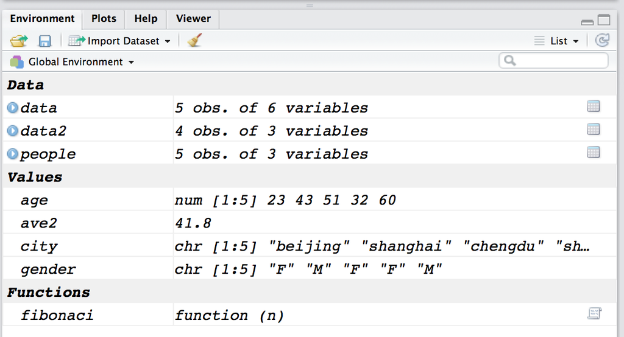

## 工作环境

- `ls()` 列出当前工作环境中的对象
- `rm(objectlist)` 移除（删除）对象,如 rm(age, city, gender)
- `save.image("myfile")` 保存工作环境到文件myfile中（默认后缀 .RData）
- `save(object, file="myfile")` 保存指定对象到一个文件中
- `load("myfile")`读取一个工作环境到当前会话中
- `attach(data)` 将data中的变量直接挪到工作环境中

```r
attach(data) # 注意工作环境中已经有了
detach(data) #
rm(data2, ave2)  # 从工作环境中移除data2
# rm(list=ls()) # 删除所有
```

## 工作目录

这是R默认读取和操作的磁盘文件夹路径，作为一个变量暂存在了工作环境中

- `getwd()` 显示当前的工作目录
- `setwd()` 修改当前的工作目录

## R中的其他对象

## 对象:类型

所有东西都是一个对象：Everything in S(R) is an object;

所有对象都属某种类型：Every object is S(R) has a class.

- 向量
- 矩阵
- **数据框**
- 数组
- 列表

## 对象：向量

- 单个数值（标量）,是向量的一种特例
- 向量的元素必须属于某种模式（mode）:可以整型（integer）、数值型（numeric）、字符型（character）、逻辑型（logical）、复数型（complex）
- 循环补齐（recycle）：在一定情况下自动延长向量
- 筛选：提取向量子集
- 向量化：对向量的每一个元素应用函数
- 使用seq()创建向量
- 使用rep()重复向量常数

```r
vector1 <- seq(2,10,2)
vector1 <- 1:10 + 2
vector2 <- 1:(10 + 2)
```

## 向量：赋值与索引

R语言中可以给向量、数据框、函数等指定一个“名字“。或则说，给名字对应的**变量**赋值。赋值操作符为等号“`=`”，也可以是"`<-`"。

```r
x <- c(1,2,3,4)
log(x)
```

```
## [1] 0.0000000 0.6931472 1.0986123 1.3862944
```

使用方括号索引一个向量：

```r
x[2] # 第二个元素
x[2:4] # 第2到4个元素
x[-4] # 减去第4个元素后
x[x>2] # 大于2的元素
```

## 向量:向量化操作

R中没有专门的标量。向量化操作是R的基本特征：

```r
nchar(c("hello world", "I am a R user"))
c(1,2,3,4) + c(3,4,5,6)
c(1,2,3,4) + c(1,2)
1:6
seq(0,1,by=0.1)
```

向量之间除了四种数字运算外，还可以进行比较，例如：

```r
c(1,2,3,4) > c(1,2,1,2)
```

```
## [1] FALSE FALSE  TRUE  TRUE
```

## 向量的计算

去掉最大值和最小值后的向量的算术均值

```r
vector <- rnorm(10)
vec_max <- max(vector)
vec_min <- min(vector)
vector_trimmed <- vector[vector<vec_max & vector>vec_min]
vec_mean <- sum(vector_trimmed)/length(vector_trimmed)
```

## 算术运算小结

- `x + y` 加法
- `x - y` 减法
- `x * y` 乘法
- `x / y` 除法
- `x ^ y` 乘幂
- `x %% y` 模运算(求余数)
- `x %/% y` 整数除法()

## 函数:

上面的基本运算符号还可以作为函数使用。R中还有很多函数来建立对应关系，大多数的函数由函数名和参数组成的。`exp`是函数名，括号中的1则是参数。又可以分为三部分构成，即输入、运算、输出。

```r
`*`(3,4)
```

```
## [1] 12
```

```r
exp(1)
```

```
## [1] 2.718282
```

```r
exp(c(1,2,3,4))
```

```
## [1]  2.718282  7.389056 20.085537 54.598150
```

## 自定义函数

我们还可以自定义函数，如求圆面积的函数

```r
myfunc <- function(r) {
  area <- pi*r^2
  return(area)
  }
print(myfunc(4))
```

```
## [1] 50.26548
```

函数在调用时会新建一个特殊子环境，用以处理函数中涉及到的变量，例如上面函数中的area变量，这种变量称为__局部变量__。因为不会在全局环境中出现而影响其它函数，使用起来非常安全。

函数内部可以调用__全局变量__，例如上面的pi。

## 矩阵

```r
vector1 <- vector2 <- vector3 <- rnorm(3) # rnorm(n, mean = 0, sd = 1)
my_matrix <- cbind(vector1,vector2,vector3)
my_matrix
```

```
##         vector1    vector2    vector3
## [1,] 0.03622517 0.03622517 0.03622517
## [2,] 0.41439079 0.41439079 0.41439079
## [3,] 0.74530770 0.74530770 0.74530770
```

```r
ifelse(my_matrix>0,1,0)
```

```
##      vector1 vector2 vector3
## [1,]       1       1       1
## [2,]       1       1       1
## [3,]       1       1       1
```

## 矩阵

```r
vector <- 1:12
dim(vector) <- c(4,3)
print(vector)
```

```
##      [,1] [,2] [,3]
## [1,]    1    5    9
## [2,]    2    6   10
## [3,]    3    7   11
## [4,]    4    8   12
```

```r
vector4 <- rnorm(8)
vector4
```

```
## [1]  1.4678487 -0.9321042 -0.8748242  0.2604450  0.5725241  0.9799572
## [7] -0.1221495  0.1000101
```

```r
matrix(vector4,nrow=2,ncol = 4, byrow = FALSE)
```

```
##            [,1]       [,2]      [,3]       [,4]
## [1,]  1.4678487 -0.8748242 0.5725241 -0.1221495
## [2,] -0.9321042  0.2604450 0.9799572  0.1000101
```

## 矩阵运算

```r
A <- matrix(c(3,1,5,2),2,2)
b <- matrix(c(4,1),ncol=1)
x <- solve(A,b)
```

## 数组

数组(Array)是多维的向量，建立数组的方法如下：

```r
a <- array(1:12,dim=c(2,3,2))
print(a)
```

```
## , , 1
##
##      [,1] [,2] [,3]
## [1,]    1    3    5
## [2,]    2    4    6
##
## , , 2
##
##      [,1] [,2] [,3]
## [1,]    7    9   11
## [2,]    8   10   12
```

```r
a[2,2,2]
a[2,1,1]
a[2,1,]  # 不能丢掉最后一个逗号，维数要一致
dim(a)
```

## 列表

列表(List)是最为灵活的数据结构.它的元素可以是不同类型，也可以有不同长度。还是用age、city、gender三个向量来构建列表。

```r
data_list = list(age=age,city=city,gender=gender)
class(data_list)
```

```
## [1] "list"
```

```r
print(data_list)
```

```
## $age
## [1] 23 43 51 32 60
##
## $city
## [1] "beijing"  "shanghai" "chengdu"  "shanghai" "beijing"
##
## $gender
## [1] "F" "M" "F" "F" "M"
```

```r
data_list$mat <- my_matrix # 矩阵
data_list$data <- data # + 数据
```

## 列表

```r
names(data_list)
```

```
## [1] "age"    "city"   "gender" "mat"    "data"
```

```r
data_list$data
```

```
##       city age gender age2 age_cat  ave
## 1  beijing  23      F   24 Group 1 41.8
## 2 shanghai  43      M   44 Group 2 41.8
## 3  chengdu  51      F   52 Group 3 41.8
## 4 shanghai  32      F   33 Group 2 41.8
## 5  beijing  60      M   61 Group 3 41.8
```

```r
length(data_list)
```

```
## [1] 5
```

```r
data_list[[4]]
```

```
##         vector1    vector2    vector3
## [1,] 0.03622517 0.03622517 0.03622517
## [2,] 0.41439079 0.41439079 0.41439079
## [3,] 0.74530770 0.74530770 0.74530770
```

## 列表内部结构

函数`str()`可用以查看一个对象的内部结构。

```r
str(data_list)
```

```
## List of 5
##  $ age   : num [1:5] 23 43 51 32 60
##  $ city  : chr [1:5] "beijing" "shanghai" "chengdu" "shanghai" ...
##  $ gender: chr [1:5] "F" "M" "F" "F" ...
##  $ mat   : num [1:3, 1:3] 0.0362 0.4144 0.7453 0.0362 0.4144 ...
##   ..- attr(*, "dimnames")=List of 2
##   .. ..$ : NULL
##   .. ..$ : chr [1:3] "vector1" "vector2" "vector3"
##  $ data  :'data.frame':  5 obs. of  6 variables:
##   ..$ city   : chr [1:5] "beijing" "shanghai" "chengdu" "shanghai" ...
##   ..$ age    : num [1:5] 23 43 51 32 60
##   ..$ gender : Factor w/ 2 levels "F","M": 1 2 1 1 2
##   ..$ age2   : num [1:5] 24 44 52 33 61
##   ..$ age_cat: chr [1:5] "Group 1" "Group 2" "Group 3" "Group 2" ...
##   ..$ ave    : num [1:5] 41.8 41.8 41.8 41.8 41.8
```

## 基础统计

## 基础统计:导入数据

```r
if(!require(car)) install.packages("car")
# data(package="car")
# ?Mroz
data(Mroz)
head(Mroz)
```

```
##   lfp k5 k618 age  wc hc       lwg    inc
## 1 yes  1    0  32  no no 1.2101647 10.910
## 2 yes  0    2  30  no no 0.3285041 19.500
## 3 yes  1    3  35  no no 1.5141279 12.040
## 4 yes  0    3  34  no no 0.0921151  6.800
## 5 yes  1    2  31 yes no 1.5242802 20.100
## 6 yes  0    0  54  no no 1.5564855  9.859
```

```r
summary(Mroz)
```

```
##   lfp            k5              k618            age          wc
##  no :325   Min.   :0.0000   Min.   :0.000   Min.   :30.00   no :541
##  yes:428   1st Qu.:0.0000   1st Qu.:0.000   1st Qu.:36.00   yes:212
##            Median :0.0000   Median :1.000   Median :43.00
##            Mean   :0.2377   Mean   :1.353   Mean   :42.54
##            3rd Qu.:0.0000   3rd Qu.:2.000   3rd Qu.:49.00
##            Max.   :3.0000   Max.   :8.000   Max.   :60.00
##    hc           lwg               inc
##  no :458   Min.   :-2.0541   Min.   :-0.029
##  yes:295   1st Qu.: 0.8181   1st Qu.:13.025
##            Median : 1.0684   Median :17.700
##            Mean   : 1.0971   Mean   :20.129
##            3rd Qu.: 1.3997   3rd Qu.:24.466
##            Max.   : 3.2189   Max.   :96.000
```

## 基础统计:连续变量

```r
mean(Mroz$inc, na.rm = TRUE)
```

```
## [1] 20.12897
```

```r
median(Mroz$inc, na.rm = TRUE)
```

```
## [1] 17.7
```

```r
sd(Mroz$inc, na.rm = TRUE)
```

```
## [1] 11.6348
```

```r
quantile(Mroz$inc, na.rm = TRUE)
```

```
##     0%    25%    50%    75%   100%
## -0.029 13.025 17.700 24.466 96.000
```

## 基础统计:分类变量

```r
table(Mroz$wc)
```

```
##
##  no yes
## 541 212
```

```r
prop.table(table(Mroz$wc))
```

```
##
##        no       yes
## 0.7184595 0.2815405
```

```r
table(Mroz$wc, Mroz$hc)
```

```
##
##        no yes
##   no  417 124
##   yes  41 171
```

## 基础统计:分类变量

```r
# 行列边缘分布
margin.table(table(Mroz$wc, Mroz$hc), 1)
```

```
##
##  no yes
## 541 212
```

```r
margin.table(table(Mroz$wc, Mroz$hc), 2)
```

```
##
##  no yes
## 458 295
```

```r
# 行列百分比
prop.table(margin.table(table(Mroz$wc, Mroz$hc), 1))
```

```
##
##        no       yes
## 0.7184595 0.2815405
```

```r
prop.table(margin.table(table(Mroz$wc, Mroz$hc), 2))
```

```
##
##        no       yes
## 0.6082337 0.3917663
```

## 基础统计:分类变量

```r
# 行列边缘分布
# install.packages("catspec")
library(catspec)
ctab(with(Mroz, table(wc,hc)), type = 'r')
```

```
##     hc    no   yes
## wc
## no     77.08 22.92
## yes    19.34 80.66
```

```r
# 行列百分比
ctab(with(Mroz, table(wc,hc)), type = c('c','n'))
```

```
##              hc     no    yes
## wc
## no  Column %     91.05  42.03
##     Count       417.00 124.00
## yes Column %      8.95  57.97
##     Count        41.00 171.00
```

## 基础统计:相关

```r
cor(Mroz[7:8])
```

```
##          lwg      inc
## lwg 1.000000 0.123202
## inc 0.123202 1.000000
```

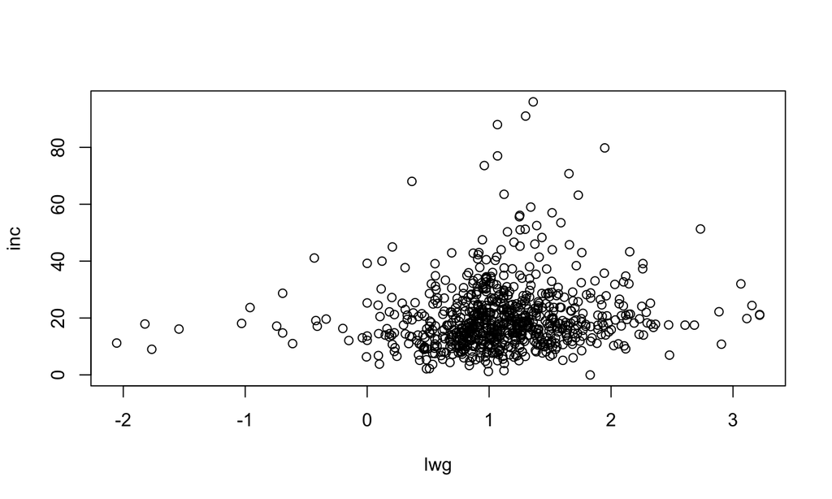

```r
plot(Mroz[7:8])
```

## 基础统计:相关

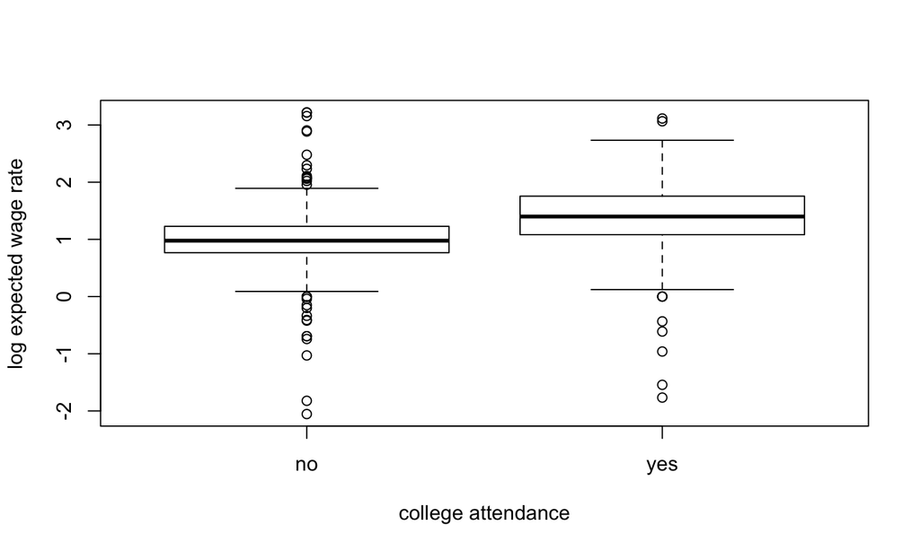

```r
boxplot(lwg ~ wc, ylab = "log expected wage rate", xlab = "college attendance",
        data = Mroz)
```

## 基础统计:模型

模型是描述数据的函数。很多时候以公式形式展现，用以预测或解释。

```
y ~ x1 + x2 + x3 ... + xn
```

一个线性回归例子：使用的数据集是R内置数据car。R语言中回归分析的函数是`lm`，将回归结果存入变量`model`中。

```r
model <- lm(formula=lwg ~ age + k5 + k618 + wc + hc +inc , data=Mroz)
# str(model)
```

## 泛函数

`summary`作为一个泛函数，可呈现回归结果：包括了各系数及其对应的P值，残差标准误和决定系数等。

```r
summary(model)
```

```
##
## Call:
## lm(formula = lwg ~ age + k5 + k618 + wc + hc + inc, data = Mroz)
##
## Residuals:
##      Min       1Q   Median       3Q      Max
## -3.10637 -0.24062 -0.00558  0.26999  2.34248
##
## Coefficients:
##              Estimate Std. Error t value Pr(>|t|)
## (Intercept)  1.121086   0.148506   7.549 1.28e-13 ***
## age         -0.002500   0.003076  -0.813  0.41671
## k5          -0.068295   0.043467  -1.571  0.11656
## k618        -0.044320   0.016854  -2.630  0.00873 **
## wcyes        0.379082   0.053814   7.044 4.24e-12 ***
## hcyes        0.018433   0.051574   0.357  0.72089
## inc          0.002217   0.001903   1.165  0.24448
## ---
## Signif. codes:  0 '***' 0.001 '**' 0.01 '*' 0.05 '.' 0.1 ' ' 1
##
## Residual standard error: 0.5566 on 746 degrees of freedom
## Multiple R-squared:  0.1097, Adjusted R-squared:  0.1025
## F-statistic: 15.31 on 6 and 746 DF,  p-value: < 2.2e-16
```

## 缺失值

真实的数据分析工作中会经常遇到数据缺失情况，缺失的数据在Ｒ中一般表示为NA。当一个数据中包含了NA时，很多函数的行为会不一样，甚至会产生错误。

```r
age <- c(27, 29, 23, 14,NA)
mean(age)
```

```
## [1] NA
```

```r
mean(age,na.rm=T)
```

```
## [1] 23.25
```

```r
is.na(age)
```

```
## [1] FALSE FALSE FALSE FALSE  TRUE
```

```r
table(is.na(age))
```

```
##
## FALSE  TRUE
##     4     1
```

## 空值

缺失值的意义是应该有数据而没有，起到一个占位符的作用。空值的意义则是完成没有，空值的表示是NULL。下面的例子中age仍然只有四个元素。

```r
age <- c(27, 29, 23, 14,NULL)
```

NULL有时候可以用来方便的删除复杂对象中的一个元素，例如删除前面data_list中的data元素。

```r
data_list$data <- NULL
```

## 数据写出

```r
write.csv(people, "data.csv", row.names = FALSE)
```

用readr包

write_csv(data, 'data.csv')

用 haven 包导出 SPSS or Stata 文件

write_spss(data, "my_spss.sav")

write_dta(data, "my_stata.dta")

## 条件语句与循环

## 条件判断

通常R代码的执行是按行顺序执行的，但有时需要根据条件来执行某些分支代码

```r
num <- 5
if (num %% 2 != 0) {
  cat(num,'is odd')
}
```

```
## 5 is odd
```

## 逻辑比较

| operator | definition |
| --- | --- |
| `<` | 小于 |
| `<=` | 小于等于 |
| `>` | 大于 |
| `>=` | 大于等于 |
| `==` | 等于 |
| `!=` | 不等于 |
| `x \| y` | `x` 或 `y` |
| `x & y` | `x` 和 `y` |

## 逻辑比较

| operator | definition |
| --- | --- |
| `is.na(x)` | 检查 `x` 为 `NA` |
| `!is.na(x)` | 检查 `x` 不是 `NA` |
| `x %in% y` | 检查 `x` 包含于 `y` |
| `!(x %in% y)` | 检查 `x` 不包含于 `y` |
| `!x` | 非 `x` |

```r
num <- 4
if (num %% 2 != 0) {
  cat(num, 'is odd')
} else {
  cat(num, 'is even')
}
```

```
## 4 is even
```

## 条件判断：if - else if

对于超过两个分支的条件判断，我们可以使用多重嵌套的if-else语句。例如计算某个数字和3相除的余数。

```r
num <- 10
if (num %% 3 == 1)  {
  cat('mode is',1)
} else if (num %% 3 == 2) {
  cat('mode is',2)
} else {
  cat('mode is',0)
}
```

```
## mode is 1
```

## 二元判断函数：ifelse

ifelse可用于向量化计算，例如判断多个数字是奇数还是偶数。

```r
num <- 1:6
ifelse(num%%2==0, yes='even',no='odd')
```

```
## [1] "odd"  "even" "odd"  "even" "odd"  "even"
```

ifelse的嵌套

```r
num <- sample(20:70,20,replace=T)
res <- ifelse(num>50,'老年',ifelse(num<30,'青年', '中年'))
```

## 循环：for

循环语句可以重复运行某一段代码。根据终止的条件，可以将循环分为for循环和while循环。

for循环的终止条件是循环的次数，例如我们计算1到100所有奇数的和。

```r
x <- 0
for (i in 1:100) {
  if (i %% 2 != 0) {
    x <- x + i
  }
}
```

实际，计算奇数之和只需要一条代码即可。

```r
sum(seq(1,100,by=2))
```

## 循环：while

while循环的终止条件是达到某一个标准，还是计算上面同样的例子。

```r
x <- 0
i <- 1
while (i < 100) {
  if (i %% 2 != 0) {
    x <- x + i
  }
  i <- i + 1
}
```

## 循环：repeat

用repeat来进行无限次的循环操作，仍是计算100以内的奇数之和。

```r
x <- 0
i <- 1
repeat  {
  if (i %% 2 != 0) {
    x <- x + i
  }
  i <- i + 1
  if (i > 100) break
}
```

## 循环：next

跳过循环中next后面的代码，而重新开始一次循环。

```r
x <- 0
i <- 0
repeat  {
  i <- i + 1
  if (i > 100) break
  if (i %% 2 == 0) next
  x <- x + i
}
```

## 循环与函数综合示例

编写自定义函数是非常容易的。计算fibonaci数字的函数：

斐波纳契数列：F(0)=0，F(1)=1, F(n)=F(n-1)+F(n-2)（n>=2，n∈N*）。这个数列从第3项开始，每一项都等于前两项之和。

```r
fibonaci <- function(n) {
  i <- 2
  x <- 1:2
  while (x[i] < n) {
    x[i+1] <- x[i-1] + x[i]
    i <- i + 1
  }
  x <- x[-i]
  return(x)
}
SeqFi <- fibonaci(100)
```

## 课后自学强化

《R语言实战》第一部分、第二部分。

把书读薄：[R语言基础小抄](http://github.com/rstudio/cheatsheets/raw/master/base-r.pdf)，并将相关的代码输入到R代码文件中。

[更多小抄](https://www.rstudio.com/resources/cheatsheets/)